# Estrutura do modelo misto

A forma matemática traduzida para uso prático

Author

Marcelo Silva

Published

October 8, 2026

## 1 A equação

O modelo misto linear (resposta contínua) tem a forma:

```
y = X * beta + Z * b + e
```

Onde:

- `y` é a variável resposta.
- `X * beta` são os efeitos fixos (o que interpretamos).
- `Z * b` são os efeitos aleatórios (a variação entre grupos).
- `e` é o erro residual.

A parte aleatória assume distribuição, em geral normal, com sua própria variância. O modelo estima as médias dos fixos e as variâncias dos aleatórios.

## 2 Traduzindo para a fórmula do R

No `lme4`, escrevemos a parte fixa à esquerda e a aleatória entre parênteses à direita:

```
lmer(resposta ~ fixos + (1 | grupo), data = d)
```

O `(1 | grupo)` diz: cada grupo tem sua própria interceptação (linha de base).

## 3 Exemplo

```r
# Ajuste o modelo mais simples com interceptação aleatória
library(lme4)
library(lmerTest)
data(sleepstudy)
modelo <- lmer(Reaction ~ Days + (1 | Subject), data = sleepstudy)
print(summary(modelo), digits = 3)
```

```
Linear mixed model fit by REML. t-tests use Satterthwaite's method [
lmerModLmerTest]
Formula: Reaction ~ Days + (1 | Subject)
   Data: sleepstudy

REML criterion at convergence: 1786.5

Scaled residuals:
   Min     1Q Median     3Q    Max
-3.226 -0.553  0.011  0.519  4.251

Random effects:
 Groups   Name        Variance Std.Dev.
 Subject  (Intercept) 1378     37.1
 Residual              960     31.0
Number of obs: 180, groups:  Subject, 18

Fixed effects:
            Estimate Std. Error      df t value Pr(>|t|)
(Intercept)  251.405      9.747  22.810    25.8   <2e-16 ***
Days          10.467      0.804 161.000    13.0   <2e-16 ***
---
Signif. codes:  0 '***' 0.001 '**' 0.01 '*' 0.05 '.' 0.1 ' ' 1

Correlation of Fixed Effects:
     (Intr)
Days -0.371
```

Repare na saída: `Random effects` traz a variância entre sujeitos; `Fixed effects` traz o efeito de `Days`.

### 3.1 Vamos observar o gráfico de macarrão

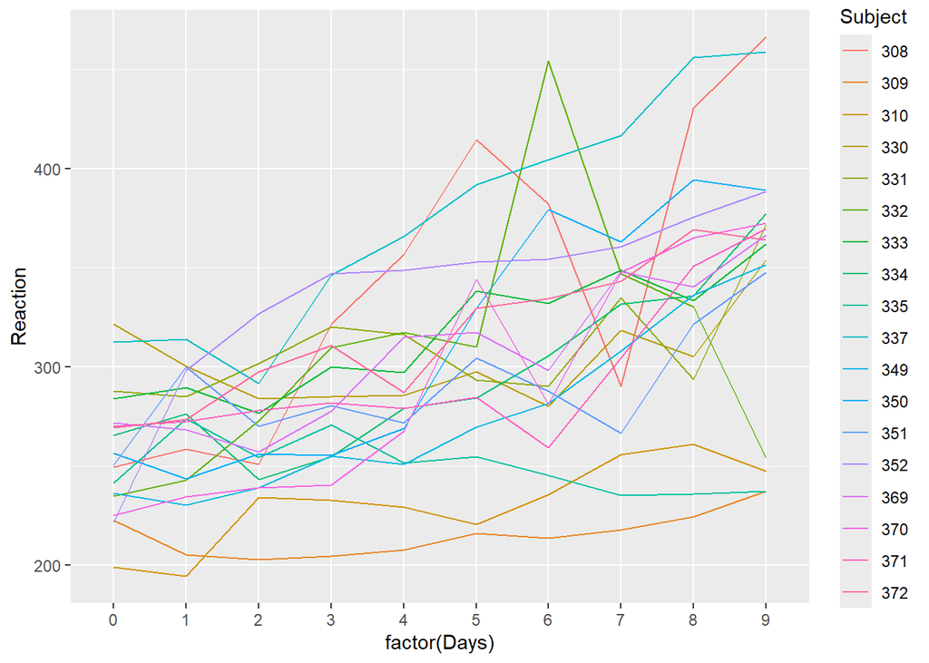

```r
library(tidyverse)
sleepstudy %>%
  ggplot(aes(x = factor(Days), y = Reaction, colour = Subject))+
  geom_line(aes(group = Subject))
```

Veja no gráfico acima, que cada a reação de cada sujeito ao longo do tempo é diferente. Vamos ver isso no modelando com a inclinação aleatória

```r
modelo_inclinacao_aletaoria <- lmer(Reaction ~ Days + (1 + Days | Subject), data = sleepstudy)
summary(modelo_inclinacao_aletaoria)
```

```
Linear mixed model fit by REML. t-tests use Satterthwaite's method [
lmerModLmerTest]
Formula: Reaction ~ Days + (1 + Days | Subject)
   Data: sleepstudy

REML criterion at convergence: 1743.6

Scaled residuals:
    Min      1Q  Median      3Q     Max
-3.9536 -0.4634  0.0231  0.4634  5.1793

Random effects:
 Groups   Name        Variance Std.Dev. Corr
 Subject  (Intercept) 612.10   24.741
          Days         35.07    5.922   0.07
 Residual             654.94   25.592
Number of obs: 180, groups:  Subject, 18

Fixed effects:
            Estimate Std. Error      df t value Pr(>|t|)
(Intercept)  251.405      6.825  17.000  36.838  < 2e-16 ***
Days          10.467      1.546  17.000   6.771 3.26e-06 ***
---
Signif. codes:  0 '***' 0.001 '**' 0.01 '*' 0.05 '.' 0.1 ' ' 1

Correlation of Fixed Effects:
     (Intr)
Days -0.138
```

**ImportantAqui vai uma observação extremamente importante**

O modelo com inclinação aleatória honestamente reconhece que a unidade de replicação para a inclinação média são os sujeitos.